# Assigment 3

ME21M038 (Shahil Chaudhari)

2022-05-16

# Problem 1

```r
library(knitr)
df = read.csv("distance.csv")
kable(df,caption = "Dissimilarity matrix of Union territory Capitals")
```

Dissimilarity matrix of Union territory Capitals

| X | leh | pondicherry | new.delhi | chandigarh | srinagar | daman | port.blair | kavaratti |
| --- | --- | --- | --- | --- | --- | --- | --- | --- |
| leh | 0 | 0 | 0 | 0 | 0 | 0 | 0 | 0 |
| pondicherry | 2480 | 0 | 0 | 0 | 0 | 0 | 0 | 0 |
| new delhi | 613 | 1878 | 0 | 0 | 0 | 0 | 0 | 0 |
| chandigarh | 388 | 2113 | 234 | 0 | 0 | 0 | 0 | 0 |
| srinagar | 256 | 2503 | 643 | 416 | 0 | 0 | 0 | 0 |
| daman | 1599 | 1201 | 1015 | 1215 | 1534 | 0 | 0 | 0 |
| port blair | 2938 | 1408 | 2485 | 2681 | 3085 | 2336 | 0 | 0 |
| kavaratti | 2669 | 797 | 2060 | 2280 | 2621 | 1090 | 2198 | 0 |

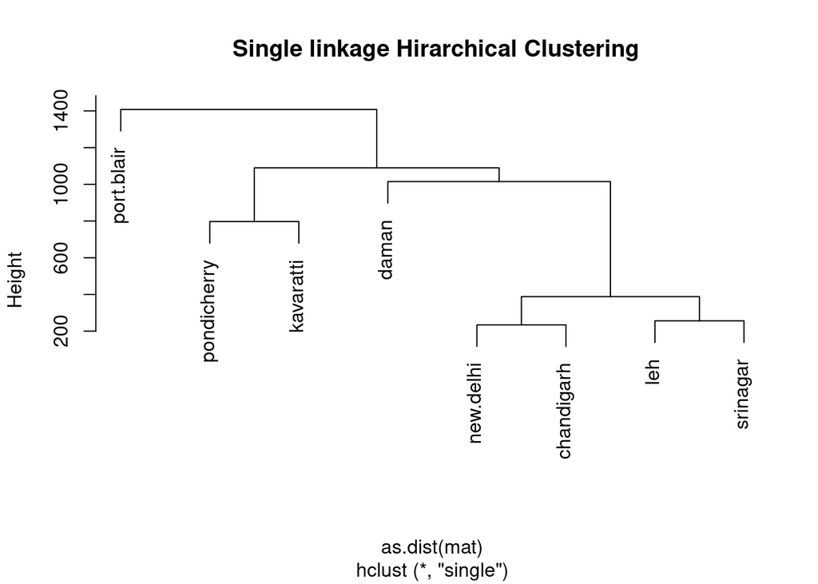

```r
df$X = NULL
mat = data.matrix(df,rownames.force = NA)

# hierarchical clustering using sigle-linkage
plot(hclust(as.dist(mat),method = "single"),main=" Single linkage Hirarchical Clustering")
```

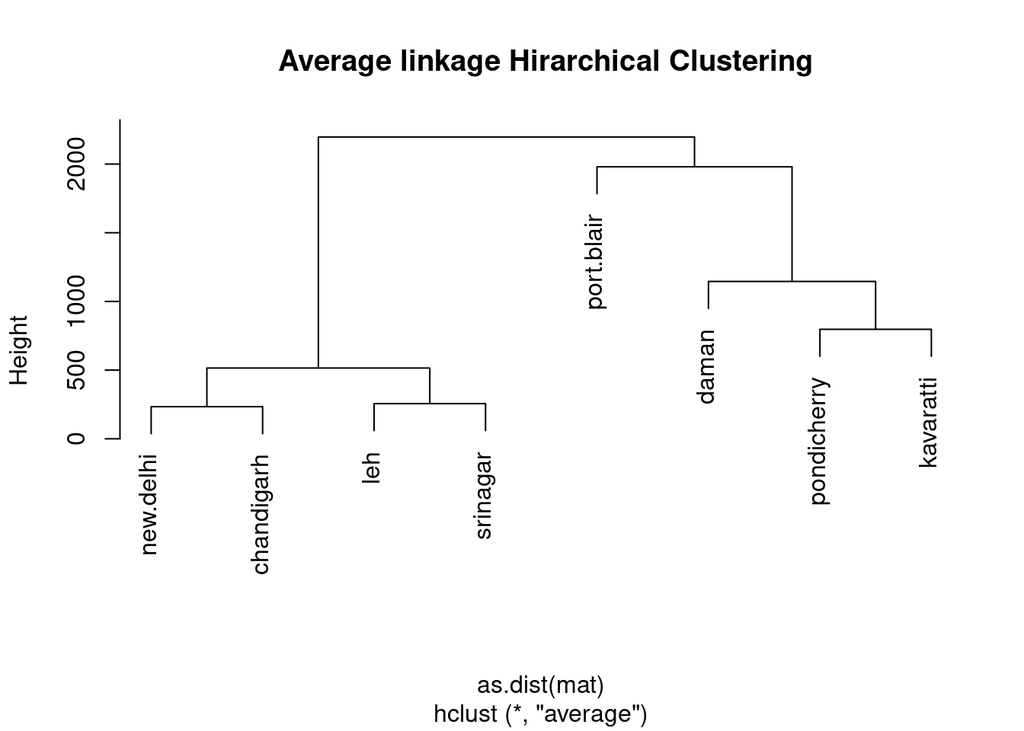

```r
# hierarchical clustering using ave-linkage
plot(hclust(as.dist(mat),method = "average"),main=" Average linkage Hirarchical Clustering")
```

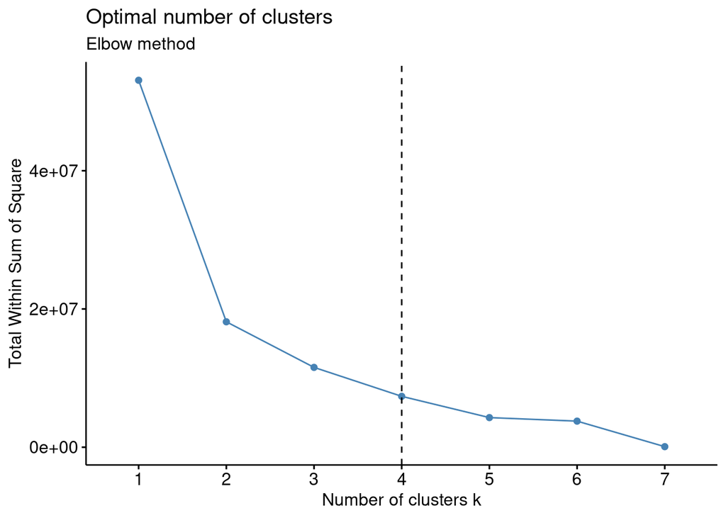

```r
# Optimal Number of cluster based on elbow method
fviz_nbclust(mat, kmeans, method = "wss",k.max = 7) + geom_vline(xintercept = 4, linetype = 2)+ labs(subtitle = "Elbow method")
```

```r
kmm = kmeans(mat,4,nstart = 50,iter.max = 15)
kmm
```

K-means clustering with 4 clusters of sizes 2, 2, 1, 3

Cluster means: leh pondicherry new.delhi chandigarh srinagar daman port.blair kavaratti 1 1240.0 0.000 0.0000 0.0000 0 0 0 0 2 2803.5 1102.500 2272.5000 2480.5000 2853 1713 1099 0 3 1599.0 1201.000 1015.0000 1215.0000 1534 0 0 0 4 419.0 2164.667 292.3333 138.6667 0 0 0 0

Clustering vector: [1] 1 1 4 4 4 3 2 2

Within cluster sum of squares by cluster: [1] 3075200 3693062 0 591682 (between_SS / total_SS = 86.1 %)

Available components:

[1] “cluster” “centers” “totss” “withinss” “tot.withinss” [6] “betweenss” “size” “iter” “ifault”

### Yes, we can apply kmean clustering at optimum value of k = 4 on this data set. We will get cluster based on zones East,West,North and South still leh and pondicherry are in same cluster which is not true.